# R Notebook

## Context

As part of Reproducible Research course which is Mandatory course for 2nd year students of Data Science and Business Analytics, we are reproducing already existing project.

Link to the project: https://www.kaggle.com/code/alfiansyahachmad/walmart-sales-analysis-eda-and-econometrics

## Description

Walmart is an American multinational retail corporation that operates a chain of hypermarkets, discount department stores, and grocery stores from the United States, headquartered in Bentonville, Arkansas (Wikipedia).

In Retail Industry, sales is the most important metric in their business model that make profit. On this reason, sales analysis will be a good way in determining business operation.

In this below dataset We’ll reproduce the wxisting analysis how Walmart Sales looks like (Trend and Seasonal) and explain wether available feature (macroeconomic condition) would be affecting it using Econometric Panel Regression (Fixed Effect and Random Effect).

##First we read the dataset

To read data, we use an url link not local file - this enables future researchers to easily read data

```r
url<-"https://raw.githubusercontent.com/WojciechMisiura/rr_project/main/Walmart_Store_sales.csv" #as we already added our dataset to github, we will read data directly from github

data<-read_csv(url)
head(data)
```

| Store | Date | Weekly_Sales | Holiday_Flag | Temperature | Fuel_Price | CPI | Unemployment |
| --- | --- | --- | --- | --- | --- | --- | --- |
| 1 | 05-02-2010 | 1643691 | 0 | 42.31 | 2.572 | 211.0964 | 8.106 |
| 1 | 12-02-2010 | 1641957 | 1 | 38.51 | 2.548 | 211.2422 | 8.106 |
| 1 | 19-02-2010 | 1611968 | 0 | 39.93 | 2.514 | 211.2891 | 8.106 |
| 1 | 26-02-2010 | 1409728 | 0 | 46.63 | 2.561 | 211.3196 | 8.106 |
| 1 | 05-03-2010 | 1554807 | 0 | 46.50 | 2.625 | 211.3501 | 8.106 |
| 1 | 12-03-2010 | 1439542 | 0 | 57.79 | 2.667 | 211.3806 | 8.106 |

```r
spec(data)
names(data)
```

```
## [1] "Store"        "Date"         "Weekly_Sales" "Holiday_Flag" "Temperature"
## [6] "Fuel_Price"   "CPI"          "Unemployment"
```

```r
colnames(data)
```

```
## [1] "Store"        "Date"         "Weekly_Sales" "Holiday_Flag" "Temperature"
## [6] "Fuel_Price"   "CPI"          "Unemployment"
```

```r
str(data)
```

```
## spc_tbl_ [6,435 × 8] (S3: spec_tbl_df/tbl_df/tbl/data.frame)
##  $ Store       : num [1:6435] 1 1 1 1 1 1 1 1 1 1 ...
##  $ Date        : chr [1:6435] "05-02-2010" "12-02-2010" "19-02-2010" "26-02-2010" ...
##  $ Weekly_Sales: num [1:6435] 1643691 1641957 1611968 1409728 1554807 ...
##  $ Holiday_Flag: num [1:6435] 0 1 0 0 0 0 0 0 0 0 ...
##  $ Temperature : num [1:6435] 42.3 38.5 39.9 46.6 46.5 ...
##  $ Fuel_Price  : num [1:6435] 2.57 2.55 2.51 2.56 2.62 ...
##  $ CPI         : num [1:6435] 211 211 211 211 211 ...
##  $ Unemployment: num [1:6435] 8.11 8.11 8.11 8.11 8.11 ...
##  - attr(*, "spec")=
##   .. cols(
##   ..   Store = col_double(),
##   ..   Date = col_character(),
##   ..   Weekly_Sales = col_double(),
##   ..   Holiday_Flag = col_double(),
##   ..   Temperature = col_double(),
##   ..   Fuel_Price = col_double(),
##   ..   CPI = col_double(),
##   ..   Unemployment = col_double()
##   .. )
##  - attr(*, "problems")=<externalptr>
```

```r
summary(data)
```

```
##      Store        Date            Weekly_Sales      Holiday_Flag
##  Min.   : 1   Length:6435        Min.   : 209986   Min.   :0.00000
##  1st Qu.:12   Class :character   1st Qu.: 553350   1st Qu.:0.00000
##  Median :23   Mode  :character   Median : 960746   Median :0.00000
##  Mean   :23                      Mean   :1046965   Mean   :0.06993
##  3rd Qu.:34                      3rd Qu.:1420159   3rd Qu.:0.00000
##  Max.   :45                      Max.   :3818686   Max.   :1.00000
##   Temperature       Fuel_Price         CPI         Unemployment
##  Min.   : -2.06   Min.   :2.472   Min.   :126.1   Min.   : 3.879
##  1st Qu.: 47.46   1st Qu.:2.933   1st Qu.:131.7   1st Qu.: 6.891
##  Median : 62.67   Median :3.445   Median :182.6   Median : 7.874
##  Mean   : 60.66   Mean   :3.359   Mean   :171.6   Mean   : 7.999
##  3rd Qu.: 74.94   3rd Qu.:3.735   3rd Qu.:212.7   3rd Qu.: 8.622
##  Max.   :100.14   Max.   :4.468   Max.   :227.2   Max.   :14.313
```

```r
colSums(is.na(data))
```

```
##        Store         Date Weekly_Sales Holiday_Flag  Temperature   Fuel_Price
##            0            0            0            0            0            0
##          CPI Unemployment
##            0            0
```

```r
any(duplicated(data))
```

```
## [1] FALSE
```

```r
data$Date <- as.Date(data$Date, format = "%d-%m-%Y")

data$Weekly_Sales <- round(data$Weekly_Sales / 1000, 3)
data$CPI <- round(data$CPI, 2)

data2 <- data

data2 <- data2[order(data2$Date), ]

panel <- data2 %>%
  group_by(Store, Date) %>%
  summarise(
    Weekly_Sales = mean(Weekly_Sales),
    Holiday_Flag = mean(Holiday_Flag),
    Temperature = mean(Temperature),
    Fuel_Price = mean(Fuel_Price),
    CPI = mean(CPI),
    Unemployment = mean(Unemployment),
    .groups = "drop"
  )

panel$Month <- month(panel$Date)
panel$Year <- year(panel$Date)

head(panel)
```

| Store | Date | Weekly_Sales | Holiday_Flag | Temperature | Fuel_Price | CPI | Unemployment | Month | Year |
| --- | --- | --- | --- | --- | --- | --- | --- | --- | --- |
| 1 | 2010-02-05 | 1643.691 | 0 | 42.31 | 2.572 | 211.10 | 8.106 | 2 | 2010 |
| 1 | 2010-02-12 | 1641.957 | 1 | 38.51 | 2.548 | 211.24 | 8.106 | 2 | 2010 |
| 1 | 2010-02-19 | 1611.968 | 0 | 39.93 | 2.514 | 211.29 | 8.106 | 2 | 2010 |
| 1 | 2010-02-26 | 1409.728 | 0 | 46.63 | 2.561 | 211.32 | 8.106 | 2 | 2010 |
| 1 | 2010-03-05 | 1554.807 | 0 | 46.50 | 2.625 | 211.35 | 8.106 | 3 | 2010 |
| 1 | 2010-03-12 | 1439.542 | 0 | 57.79 | 2.667 | 211.38 | 8.106 | 3 | 2010 |

```r
data_sub <- data[, !(names(data) %in% c('Month', 'Year', 'Store'))]

summary(data_sub)
```

```
##       Date             Weekly_Sales     Holiday_Flag      Temperature
##  Min.   :2010-02-05   Min.   : 210.0   Min.   :0.00000   Min.   : -2.06
##  1st Qu.:2010-10-08   1st Qu.: 553.4   1st Qu.:0.00000   1st Qu.: 47.46
##  Median :2011-06-17   Median : 960.7   Median :0.00000   Median : 62.67
##  Mean   :2011-06-17   Mean   :1047.0   Mean   :0.06993   Mean   : 60.66
##  3rd Qu.:2012-02-24   3rd Qu.:1420.2   3rd Qu.:0.00000   3rd Qu.: 74.94
##  Max.   :2012-10-26   Max.   :3818.7   Max.   :1.00000   Max.   :100.14
##    Fuel_Price         CPI         Unemployment
##  Min.   :2.472   Min.   :126.1   Min.   : 3.879
##  1st Qu.:2.933   1st Qu.:131.7   1st Qu.: 6.891
##  Median :3.445   Median :182.6   Median : 7.874
##  Mean   :3.359   Mean   :171.6   Mean   : 7.999
##  3rd Qu.:3.735   3rd Qu.:212.7   3rd Qu.: 8.622
##  Max.   :4.468   Max.   :227.2   Max.   :14.313
```

## A. Aggregate Time Series Analysis

How is the Walmart aggregate sales looks like? Does this sales has seasonal component? ## Below is the Aggregate Sales for the whole Walmart Store

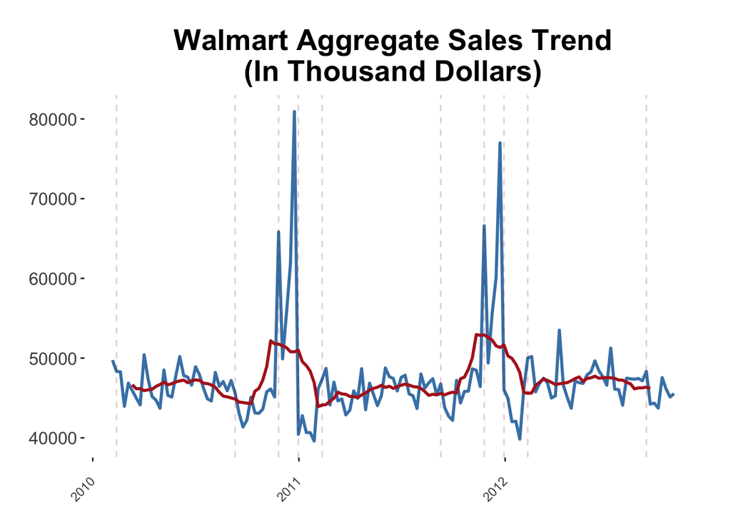

```r
holiday_date <- as.Date(c('2010-02-12', '2010-09-10',
                          '2010-11-26', '2010-12-31',
                          '2011-02-11', '2011-09-09',
                          '2011-11-25', '2011-12-30',
                          '2012-02-10', '2012-09-07'))

locate <- as.Date('2011-05-06')

agg_sales <- aggregate(panel$Weekly_Sales, by = list(Date = panel$Date), FUN = sum)

ggplot(agg_sales, aes(x = Date, y = x)) +
  geom_line(color = "steelblue", size = 1) +
  geom_line(data = transform(agg_sales, x = rollmean(x, k = 12, fill = NA)),
            aes(x = Date, y = x), color = "firebrick", size = 1) +
  geom_vline(xintercept = as.numeric(holiday_date), color = "darkred", alpha = 0.2, linetype = "dashed") +
  labs(title = "Walmart Aggregate Sales Trend\n(In Thousand Dollars)",
       x = NULL, y = NULL) +
  theme_bw() +
  theme(plot.title = element_text(size = 20, face = "bold", hjust = 0.5),
        axis.text.x = element_text(angle = 45, vjust = 0.5, hjust = 1),
        axis.text.y = element_text(size = 12),
        axis.title = element_text(size = 14),
        panel.grid.major = element_blank(),
        panel.grid.minor = element_blank(),
        panel.border = element_blank(),
        panel.background = element_rect(fill = "white"),
        plot.margin = margin(20, 20, 20, 20, "pt"))
```

The graph tell us that this data contain seasonal component on holiday date (red line). Walmart sales seems rapidly increased when holiday date taking place. But in the other side (non-holiday date), sales tend to be in stagnant position. It means we have to be careful interpreting sales volume (Growth sales would be good metrics). Before that, next we’ll discuss more little depth which holiday contribute more in Walmart sales aggregately.

## Below are the detail about sales in holiday, are thanksgiving holiday have highest sales?

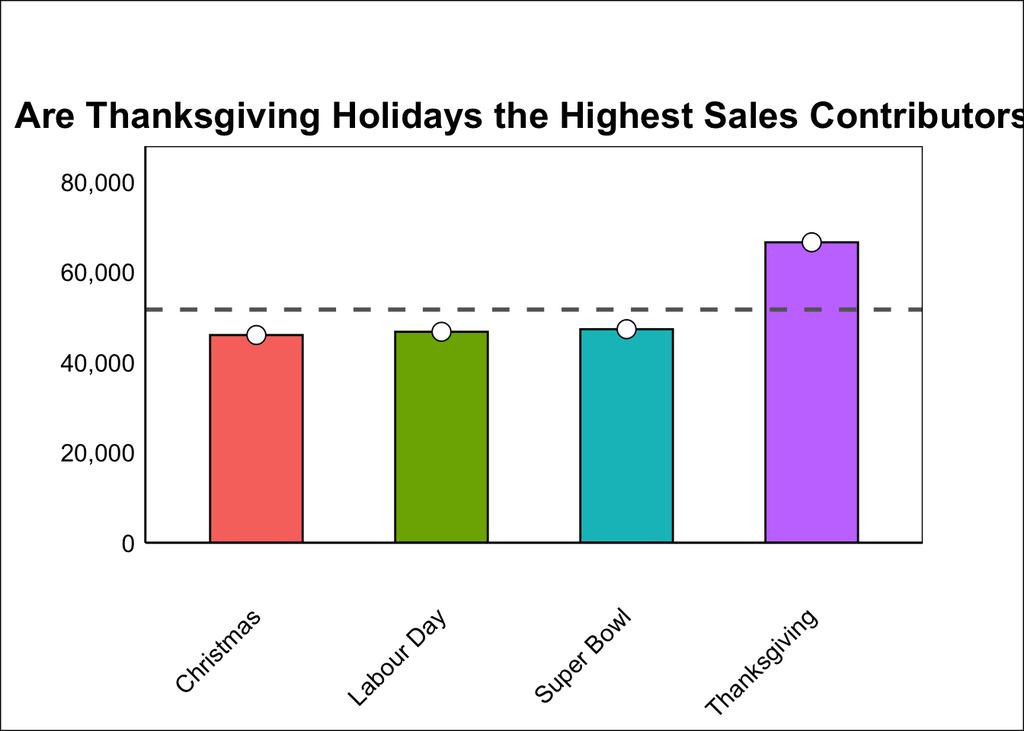

```r
super_bowl <- c('2010-02-12', '2011-02-11', '2012-02-10')
labour_day <- c('2010-09-10', '2011-09-09', '2012-09-07')
thanksgiving <- c('2010-11-26', '2011-11-25', '2012-11-23')
christmas <- c('2010-12-31', '2011-12-30', '2012-12-28')

super_bowl_sales <- sum(data$Weekly_Sales[data$Date == '2011-02-11'])
labour_day_sales <- sum(data$Weekly_Sales[data$Date == '2011-09-09'])
thanksgiving_sales <- sum(data$Weekly_Sales[data$Date == '2011-11-25'])
christmas_sales <- sum(data$Weekly_Sales[data$Date == '2011-12-30'])

holiday_sales <- data.frame(
  Holiday = c("Super Bowl", "Labour Day", "Thanksgiving", "Christmas"),
  Sales = c(super_bowl_sales, labour_day_sales, thanksgiving_sales, christmas_sales)
)

holiday_sales$Sales <- round(holiday_sales$Sales, 2)

ggplot(holiday_sales, aes(x = Holiday, y = Sales, fill = Holiday)) +
  geom_bar(stat = "identity", width = 0.5, color = "black") +
  geom_text(aes(label = paste0(Sales, "k")), vjust = -0.5, size = 8, fontface = "bold", color = "white") +
  labs(title = "Are Thanksgiving Holidays the Highest Sales Contributors?",
       x = NULL, y = NULL) +
  theme_minimal() +
  theme(axis.text.x = element_text(angle = 45, hjust = 1, vjust = 0.5, size = 12, color = "black"),
        axis.text.y = element_text(size = 12, color = "black"),
        axis.title = element_text(size = 14, color = "black", face = "bold"),
        panel.grid.major = element_blank(),
        panel.grid.minor = element_blank(),
        plot.title = element_text(size = 18, color = "black", face = "bold", hjust = 0.5),
        plot.caption = element_text(size = 10, color = "gray50", hjust = 1),
        plot.background = element_rect(fill = "white"),
        panel.border = element_rect(color = "black", fill = NA),
        axis.line = element_line(color = "black"),
        plot.margin = margin(50, 50, 30, 30)) +
  scale_y_continuous(labels = comma, expand = expansion(mult = c(0, 0.1))) +
  coord_cartesian(ylim = c(0, max(holiday_sales$Sales) * 1.2)) +
  annotate("text", x = holiday_sales$Holiday, y = holiday_sales$Sales,
           label = paste0(holiday_sales$Sales, "k"), vjust = -0.5, size = 6, fontface = "bold", color = "white") +
  geom_hline(yintercept = mean(holiday_sales$Sales), linetype = "dashed", color = "gray40", size = 1) +
  geom_point(aes(x = holiday_sales$Holiday, y = holiday_sales$Sales),
             shape = 21, fill = "white", color = "black", size = 4) +
  guides(fill = "none")
```

```r
pivot_table <- panel %>%
  group_by(Date) %>%
  summarize(Weekly_Sales = sum(Weekly_Sales),
            Temperature = mean(Temperature),
            Fuel_Price = mean(Fuel_Price),
            CPI = mean(CPI),
            Unemployment = mean(Unemployment)) %>%
  tidyr::separate(Date, into = c("Year", "Month", "Day"), sep = "-") %>%
  select(-Day)

head(pivot_table)
```

| Year | Month | Weekly_Sales | Temperature | Fuel_Price | CPI | Unemployment |
| --- | --- | --- | --- | --- | --- | --- |
| 2010 | 02 | 49750.74 | 34.03733 | 2.717844 | 167.7298 | 8.619311 |
| 2010 | 02 | 48336.68 | 34.15133 | 2.694022 | 167.8269 | 8.619311 |
| 2010 | 02 | 48277.00 | 37.71978 | 2.672067 | 167.8738 | 8.619311 |
| 2010 | 02 | 43968.57 | 39.24356 | 2.683933 | 167.9104 | 8.619311 |
| 2010 | 03 | 46871.47 | 42.91733 | 2.731200 | 167.9491 | 8.619311 |
| 2010 | 03 | 45925.39 | 47.43244 | 2.774422 | 167.9842 | 8.619311 |

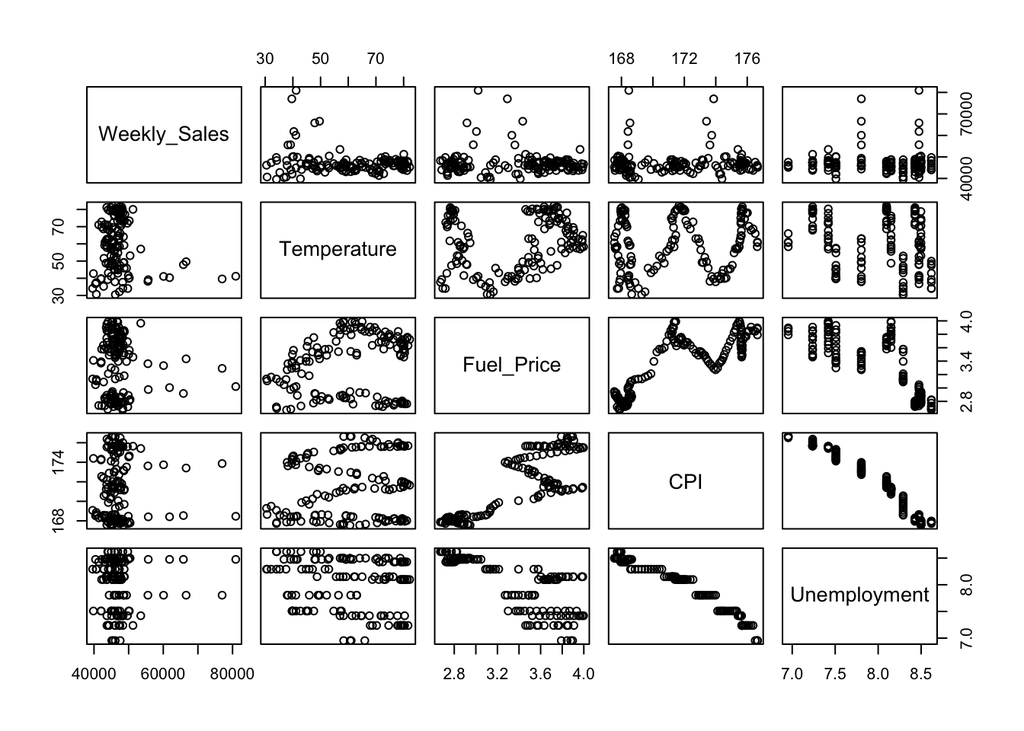

```r
pairplot <- pivot_table[, !(names(pivot_table) %in% c("Month", "Year"))]
pairs(pairplot)
```

```r
cor_matrix <- cor(pivot_table[, !(names(pivot_table) %in% c("Month", "Year"))])
cor_matrix
```

```
##              Weekly_Sales Temperature  Fuel_Price         CPI Unemployment
## Weekly_Sales  1.000000000  -0.1591599 -0.05672248  0.02339266  0.003523566
## Temperature  -0.159159882   1.0000000  0.20575698  0.15941497 -0.168459802
## Fuel_Price   -0.056722483   0.2057570  1.00000000  0.82469284 -0.747204625
## CPI           0.023392660   0.1594150  0.82469284  1.00000000 -0.977429167
## Unemployment  0.003523566  -0.1684598 -0.74720463 -0.97742917  1.000000000
```

It seems that sales have less correlation with macroeconomic condition. Possible reason of this realtionship that because we use weekly data and macroeconomic variables like CPI, unemployment, fuel price have slow/rigid change in the short run.

[figure not shown]

```r
growth_df <- panel %>%
  select(Date, Weekly_Sales) %>%
  group_by(Date = as.yearmon(Date)) %>%
  summarize(Weekly_Sales = sum(Weekly_Sales)) %>%
  ungroup() %>%
  mutate(Rolling_Month = lag(Weekly_Sales),
         Growth_MoM = round((Weekly_Sales - Rolling_Month) / Rolling_Month * 100, 2))

growth_df <- growth_df %>%
  dplyr::mutate(growth_df = dplyr::lead(growth_df)) %>%
  dplyr::select(-c(3, 4))

growth_df$Year <- year(growth_df$Date)
growth_df$Month <- month(growth_df$Date)

super_bowl <- c('2010-02-28', '2011-02-28', '2012-02-28')
labour_day <- c('2010-09-30', '2011-09-30', '2012-09-30')
thanksgiving <- c('2010-11-30', '2011-11-30', '2012-11-30')
christmas <- c('2010-12-31', '2011-12-31', '2012-12-31')

g2010 <- growth_df %>%
  filter(Year == 2010) %>%
  summarize(Month = Month[which.max(growth_df$Growth_MoM)], Growth_MoM = max(growth_df$Growth_MoM))

g2011 <- growth_df %>%
  filter(Year == 2011) %>%
  summarize(Month = Month[which.max(growth_df$Growth_MoM)], Growth_MoM = max(growth_df$Growth_MoM))

g2012 <- growth_df %>%
  filter(Year == 2012) %>%
  summarize(Month = Month[which.max(growth_df$Growth_MoM)], Growth_MoM = max(growth_df$Growth_MoM))





# Create a data frame with the text labels
text_labels <- data.frame(
  x = c(0.7, 0.2, 0.2, 0.75, 0.75, 0.75, 1.3, 1.3, 1.3),
  y = c(0.85, 0.5, 0.3, 0.5, 0.3, 0.1, 0.5, 0.3, 0.1),
  label = c("Highest Sales MoM Growth", "December", "42.35%", "December", "37.07%", "2011", "October", "27.46%", "2012"),
  #color = c("black", "blue", "gray", "blue", "gray", "gray", "blue", "gray", "gray"),
  #size = c(6, 12, 8, 12, 8, 8, 12, 8, 8),
  fontface = c("bold", "bold", "bold", "bold", "bold", "bold", "bold", "bold", "bold"),
  family = c("sans", "mono", "mono", "mono", "mono", "mono", "mono", "mono", "mono"),
  vjust = c(0, 0.5, 0.5, 0.5, 0.5, 0.5, 0.5, 0.5, 0.5),
  hjust = c(0.5, 0.5, 0.5, 0.5, 0.5, 0.5, 0.5, 0.5, 0.5)
)

# Create the plot
fig <- ggplot() +
  theme_void() +
  theme(plot.margin = margin(0, 0, 0, 0, "cm"))

# Add text elements to the plot
fig <- fig +
  geom_text(data = text_labels, aes(x = x, y = y, label = label,
                                    fontface = fontface, family = family, vjust = vjust, hjust = hjust))

# Show the plot
print(fig)
```

Although Thanksgiving holiday on November has highest sales than the other holiday, December has the highest growth sales happening before Christmas in 2010 and 2011. It stated that in 2012, October become the highest MoM sales growth because we don’t have sales data on December 2012.

# Sales Panel Analysis by Store

## Which store perform better?

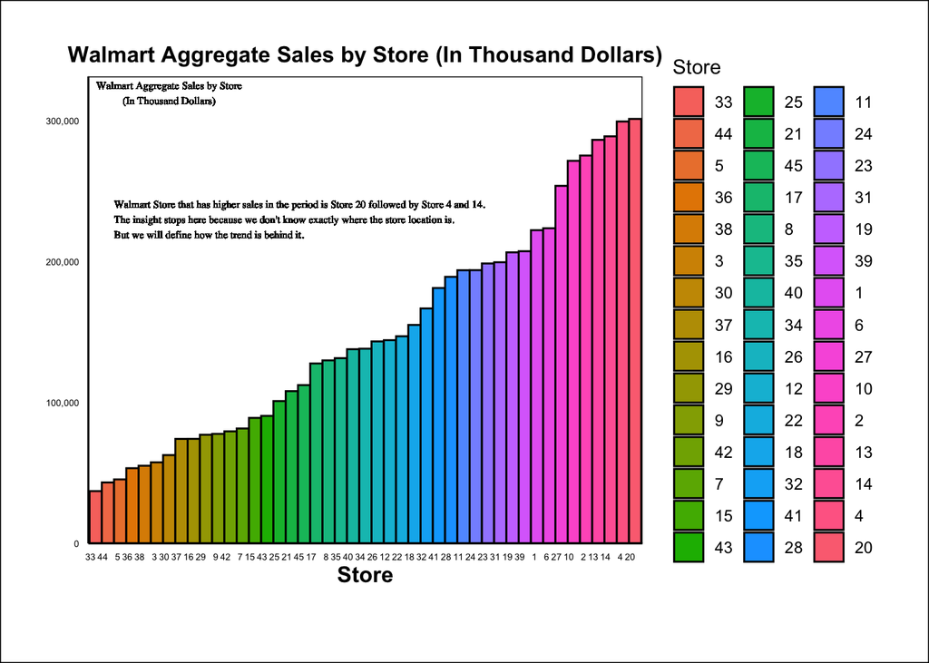

```r
sales_store <- panel %>%
  group_by(Store) %>%
  summarize(Weekly_Sales = sum(Weekly_Sales))

sales_store <- sales_store %>%
  arrange(Weekly_Sales) %>%
  mutate(Store = factor(Store, levels = unique(Store)))

ggplot(sales_store, aes(x = Store, y = Weekly_Sales, fill = Store)) +
  geom_bar(stat = "identity", width = 1, color = "black") +
  labs(title = "Walmart Aggregate Sales by Store (In Thousand Dollars)",
       x = "Store", y = NULL, caption = "") +
  theme_minimal() +
  theme(axis.text.x = element_text(angle = 0, hjust = 1, vjust = 0.5, size = 5, color = "black"),
        axis.text.y = element_text(size = 5, color = "black"),
        axis.title = element_text(size = 12, color = "black", face = "bold"),
        panel.grid.major = element_blank(),
        panel.grid.minor = element_blank(),
        plot.title = element_text(size = 12, color = "black", face = "bold", hjust = 0.5),
        plot.caption = element_text(size = 12, color = "gray50", hjust = 1),
        plot.background = element_rect(fill = "white"),
        panel.border = element_rect(color = "black", fill = NA),
        axis.line = element_line(color = "black"),
        plot.margin = margin(25, 25, 25, 25)) +
  scale_y_continuous(labels = comma, expand = expansion(mult = c(0, 0.1))) +
  geom_text(x = 7, y = 320000, label = "Walmart Aggregate Sales by Store\n(In Thousand Dollars)",
            size = 2, family = "serif", color = "black", hjust = 0.5) +
  geom_text(x = 2.5, y = 230000, label = "Walmart Store that has higher sales in the period is Store 20 followed by Store 4 and 14.\nThe insight stops here because we don't know exactly where the store location is.\nBut we will define how the trend is behind it.",
            size = 2, family = "serif", color = "black", hjust = 0)
```

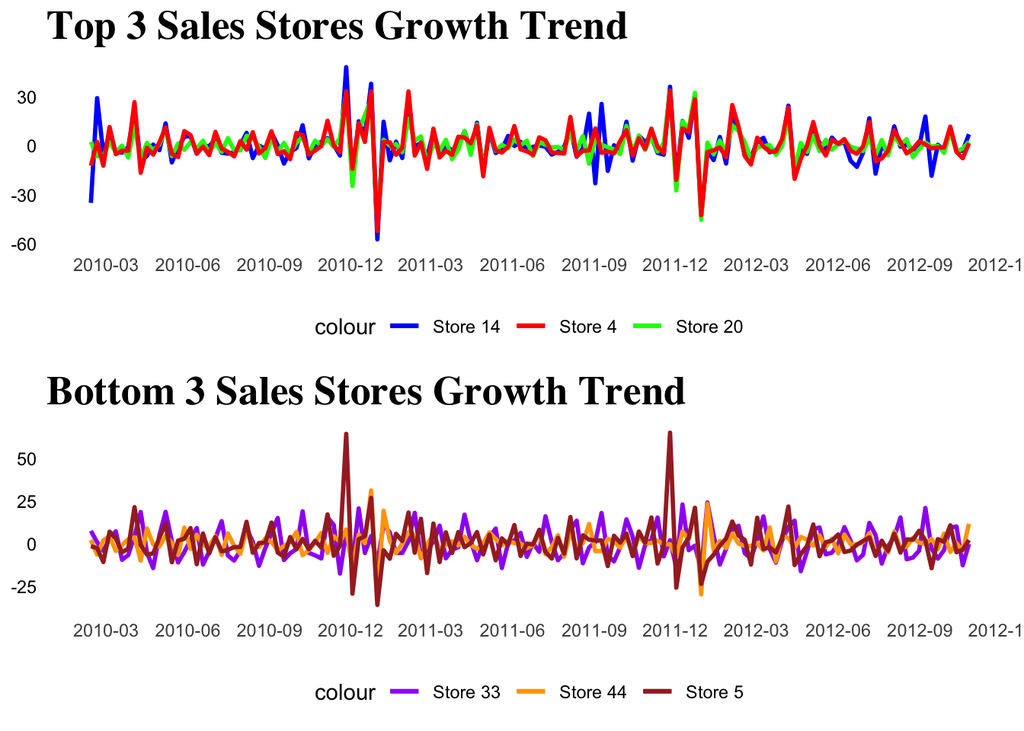

```r
# Highest Store
store14 <- panel[panel$Store == 14, c("Date", "Weekly_Sales")]
store14$roll <- dplyr::lag(store14$Weekly_Sales)
store14$weekly_growth <- round((store14$Weekly_Sales - store14$roll) / store14$roll * 100, 2)
store14 <- dplyr::lead(store14)

store4 <- panel[panel$Store == 4, c("Date", "Weekly_Sales")]
store4$roll <- dplyr::lag(store4$Weekly_Sales)
store4$weekly_growth <- round((store4$Weekly_Sales - store4$roll) / store4$roll * 100, 2)
store4 <- dplyr::lead(store4)

store20 <- panel[panel$Store == 20, c("Date", "Weekly_Sales")]
store20$roll <- dplyr::lag(store20$Weekly_Sales)
store20$weekly_growth <- round((store20$Weekly_Sales - store20$roll) / store20$roll * 100, 2)
store20 <- dplyr::lead(store20)

# Lowest Store
store33 <- panel[panel$Store == 33, c("Date", "Weekly_Sales")]
store33$roll <- dplyr::lag(store33$Weekly_Sales)
store33$weekly_growth <- round((store33$Weekly_Sales - store33$roll) / store33$roll * 100, 2)
store33 <- dplyr::lead(store33)

store44 <- panel[panel$Store == 44, c("Date", "Weekly_Sales")]
store44$roll <- dplyr::lag(store44$Weekly_Sales)
store44$weekly_growth <- round((store44$Weekly_Sales - store44$roll) / store44$roll * 100, 2)
store44 <- dplyr::lead(store44)

store5 <- panel[panel$Store == 5, c("Date", "Weekly_Sales")]
store5$roll <- dplyr::lag(store5$Weekly_Sales)
store5$weekly_growth <- round((store5$Weekly_Sales - store5$roll) / store5$roll * 100, 2)
store5 <- dplyr::lead(store5)

# Define locate1
locate1 <- as.Date('2011-02-01')

# Create the first plot for top 3 stores
plot_top <- ggplot() +
  theme_minimal() +
  theme(panel.grid = element_blank(),
        axis.text.y = element_text(color = "black"),
        axis.title.x = element_blank(),
        axis.title.y = element_blank(),
        plot.title = element_text(color = "black", size = 20, face = "bold", family = "serif"))

plot_top <- plot_top +
  geom_line(data = store14, aes(x = Date, y = weekly_growth, color = "Store 14"), size = 1) +
  geom_line(data = store4, aes(x = Date, y = weekly_growth, color = "Store 4"), size = 1) +
  geom_line(data = store20, aes(x = Date, y = weekly_growth, color = "Store 20"), size = 1) +
  scale_color_manual(values = c("blue", "red", "green"),
                     labels = c("Store 14", "Store 4", "Store 20")) +
  labs(title = "Top 3 Sales Stores Growth Trend",
       y = "Weekly Growth (%)") +
  theme(legend.position = "bottom")

plot_top <- plot_top +
  annotate("text", x = max(store14$Date), y = store14$weekly_growth[length(store14$weekly_growth)],
           label = paste0("Latest: ", store14$weekly_growth[length(store14$weekly_growth)]),
           color = "black", size = 6, fontface = "bold", family = "serif", hjust = 1, vjust = -0.5) +
  annotate("text", x = max(store4$Date), y = store4$weekly_growth[length(store4$weekly_growth)],
           label = paste0("Latest: ", store4$weekly_growth[length(store4$weekly_growth)]),
           color = "black", size = 6, fontface = "bold", family = "serif", hjust = 1, vjust = -0.5) +
  annotate("text", x = max(store20$Date), y = store20$weekly_growth[length(store20$weekly_growth)],
           label = paste0("Latest: ", store20$weekly_growth[length(store20$weekly_growth)]),
           color = "black", size = 6, fontface = "bold", family = "serif", hjust = 1, vjust = -0.5) +
  scale_x_date(labels = date_format("%Y-%m"), breaks = date_breaks("3 months"))

# Create the second plot for bottom 3 stores
plot_bottom <- ggplot() +
  theme_minimal() +
  theme(panel.grid = element_blank(),
        axis.text.y = element_text(color = "black"),
        axis.title.x = element_blank(),
        axis.title.y = element_blank(),
        plot.title = element_text(color = "black", size = 20, face = "bold", family = "serif"))

plot_bottom <- plot_bottom +
  geom_line(data = store33, aes(x = Date, y = weekly_growth, color = "Store 33"), size = 1) +
  geom_line(data = store44, aes(x = Date, y = weekly_growth, color = "Store 44"), size = 1) +
  geom_line(data = store5, aes(x = Date, y = weekly_growth, color = "Store 5"), size = 1) +
  scale_color_manual(values = c("purple", "orange", "brown"),
                     labels = c("Store 33", "Store 44", "Store 5")) +
  labs(title = "Bottom 3 Sales Stores Growth Trend",
       x = "Date",
       y = "Weekly Growth (%)") +
  theme(legend.position = "bottom")

plot_bottom <- plot_bottom +
  annotate("text", x = max(store33$Date), y = store33$weekly_growth[length(store33$weekly_growth)],
           label = paste0("Latest: ", store33$weekly_growth[length(store33$weekly_growth)]),
           color = "black", size = 6, fontface = "bold", family = "serif", hjust = 1, vjust = -0.5) +
  annotate("text", x = max(store44$Date), y = store44$weekly_growth[length(store44$weekly_growth)],
           label = paste0("Latest: ", store44$weekly_growth[length(store44$weekly_growth)]),
           color = "black", size = 6, fontface = "bold", family = "serif", hjust = 1, vjust = -0.5) +
  annotate("text", x = max(store5$Date), y = store5$weekly_growth[length(store5$weekly_growth)],
           label = paste0("Latest: ", store5$weekly_growth[length(store5$weekly_growth)]),
           color = "black", size = 6, fontface = "bold", family = "serif", hjust = 1, vjust = -0.5) +
  scale_x_date(labels = date_format("%Y-%m"), breaks = date_breaks("3 months"))

# Arrange the plots
plot_combined <- cowplot::plot_grid(plot_top, plot_bottom, ncol = 1, align = "v")
# Display the combined plot
plot_combined
```

Below is the analysis of 6 stores separately.

[figure not shown]

```r
# Create quarterly month labels
quarterly_months <- data.frame(
  Date = as.Date(c("2011-01-01", "2011-04-01", "2011-07-01", "2011-10-01")),
  Label = c("Jan", "Apr", "Jul", "Oct")
)

# Create the plot for Store 14
plot_store14 <- ggplot(store14, aes(x = Date, y = weekly_growth)) +
  geom_line(color = "blue") +
  labs(title = "Store 14 - Weekly Growth", x = "Date", y = "Weekly Growth") +
  theme_minimal() +
  theme(legend.position = "none") +
  scale_x_date(date_breaks = "3 months", date_labels = "%b")

# Create the plot for Store 4
plot_store4 <- ggplot(store4, aes(x = Date, y = weekly_growth)) +
  geom_line(color = "red") +
  labs(title = "Store 4 - Weekly Growth", x = "Date", y = "Weekly Growth") +
  theme_minimal() +
  theme(legend.position = "none") +
  scale_x_date(date_breaks = "3 months", date_labels = "%b")

# Create the plot for Store 20
plot_store20 <- ggplot(store20, aes(x = Date, y = weekly_growth)) +
  geom_line(color = "green") +
  labs(title = "Store 20 - Weekly Growth", x = "Date", y = "Weekly Growth") +
  theme_minimal() +
  theme(legend.position = "none") +
  scale_x_date(date_breaks = "3 months", date_labels = "%b")

# Create the plot for Store 33
plot_store33 <- ggplot(store33, aes(x = Date, y = weekly_growth)) +
  geom_line(color = "purple") +
  labs(title = "Store 33 - Weekly Growth", x = "Date", y = "Weekly Growth") +
  theme_minimal() +
  theme(legend.position = "none") +
  scale_x_date(date_breaks = "3 months", date_labels = "%b")

# Create the plot for Store 44
plot_store44 <- ggplot(store44, aes(x = Date, y = weekly_growth)) +
  geom_line(color = "orange") +
  labs(title = "Store 44 - Weekly Growth", x = "Date", y = "Weekly Growth") +
  theme_minimal() +
  theme(legend.position = "none") +
  scale_x_date(date_breaks = "3 months", date_labels = "%b")

# Create the plot for Store 5
plot_store5 <- ggplot(store5, aes(x = Date, y = weekly_growth)) +
  geom_line(color = "gray") +
  labs(title = "Store 5 - Weekly Growth", x = "Date", y = "Weekly Growth") +
  theme_minimal() +
  theme(legend.position = "none") +
  scale_x_date(date_breaks = "3 months", date_labels = "%b")

# Combine the plots using the '+' operator from the patchwork package
combined_plot <- plot_store14 + plot_store4 + plot_store20 + plot_store33 + plot_store44 + plot_store5 +
  plot_layout(ncol = 1)

# Annotate quarterly month labels
combined_plot <- combined_plot +
  annotate(
    "text",
    x = quarterly_months$Date,
    y = -10,
    label = quarterly_months$Label,
    color = "gray",
    size = 4,
    hjust = 0.5,
    vjust = 0.5
  )

# Show the combined plot
combined_plot
```

```r
# Sort sales_store dataframe by Weekly_Sales in descending order
sales_store <- sales_store[order(-sales_store$Weekly_Sales),]

# Get the top 4 stores
store_list <- head(sales_store$Store, 4)

# Calculate the sum of Weekly_Sales by Store and Year
sales <- panel %>%
  group_by(Store, Year) %>%
  summarize(Weekly_Sales = sum(Weekly_Sales)) %>%
  ungroup()
# Calculate the mean Temperature by Store and Year
temp <- panel %>%
  group_by(Store, Year) %>%
  summarize(Temperature = mean(Temperature)) %>%
  ungroup()
```

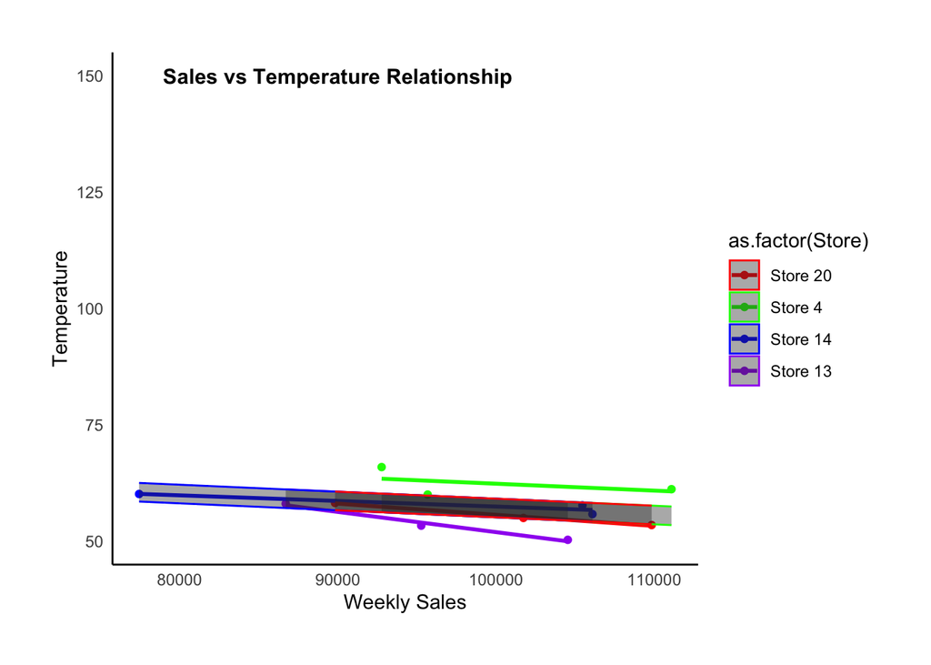

```r
# Create a data frame for plotting
plot_data <- data.frame(sales, temp)

# Filter the data for the selected stores
plot_data <- plot_data %>% filter(Store %in% store_list)

# Create the plot
plot <- ggplot(plot_data, aes(x = Weekly_Sales, y = Temperature, color = as.factor(Store))) +
  geom_point() +
  geom_smooth(aes(group = Store), method = "lm", se = FALSE) +
  geom_ribbon(aes(ymin = fitted(lm(Temperature ~ Weekly_Sales, data = plot_data)) - 2,
                  ymax = fitted(lm(Temperature ~ Weekly_Sales, data = plot_data)) + 2),
              alpha = 0.4) +
  labs(x = "Weekly Sales", y = "Temperature") +
  theme_minimal()

# Remove top and right spines
plot <- plot + theme(panel.border = element_blank(),
                     panel.grid.major = element_blank(),
                     panel.grid.minor = element_blank(),
                     axis.line = element_line(color = "black"))

# Add legend with custom labels and colors
plot <- plot + scale_color_manual(values = c("red", "green", "blue", "purple"),
                                  breaks = store_list,
                                  labels = paste0("Store ", store_list))

# Add title text
plot <- plot + annotate("text", x = 90000, y = 150,
                        label = "Sales vs Temperature Relationship",
                        color = "black", size = 4, fontface = "bold")

# Adjust plot layout
plot <- plot + theme(plot.margin = margin(1, 1, 1, 1, "cm"))

# Show the plot
plot
```

Here we test the relationship between temperature and sales since this variable has the highest correlation among all feature. As we see that the slope (relative change in dependent variable if independent variable change) are small in all highest sales top 4 store

## Econometrics Analysis: Does Macroeconomic Variable Affect Weekly Sales?

Econometrics is a tool that economist used for knowing how the causal relationship between dependent (target) variable and independent (feature matrix) variable. There are three types of data: 1.) Cross-section, 2.) Time Series, 3.) Pooled Data (Cross-section and Time Series).

Basically, there are three types of regression for panel data: 1. **PooledOLS** can be described as simple OLS (Ordinary Least Squared) model that is performed on panel data. It ignores time and individual characteristics and focuses only on dependencies between the individuums 2. **Fixed-Effects (FE) Model**: The FE-model determines individual effects of unobserved, independent variables as constant (“fix“) over time 3. **Random-Effects (RE) Model**: RE-models determine individual effects of unobserved, independent variables as random variables over time. They are able to “switch” between OLS and FE and hence, can focus on both, dependencies between and within individuals

Here we will run the data into all the method.

```r
panel_data <- panel %>%
  select(-Month, -Year, -Holiday_Flag) %>%
  arrange(Store, Date) %>%
  mutate(Date = as.Date(Date))

panel_data
```

| Store | Date | Weekly_Sales | Temperature | Fuel_Price | CPI | Unemployment |
| --- | --- | --- | --- | --- | --- | --- |
| 1 | 2010-02-05 | 1643.691 | 42.31 | 2.572 | 211.10 | 8.106 |
| 1 | 2010-02-12 | 1641.957 | 38.51 | 2.548 | 211.24 | 8.106 |
| 1 | 2010-02-19 | 1611.968 | 39.93 | 2.514 | 211.29 | 8.106 |
| 1 | 2010-02-26 | 1409.728 | 46.63 | 2.561 | 211.32 | 8.106 |
| 1 | 2010-03-05 | 1554.807 | 46.50 | 2.625 | 211.35 | 8.106 |
| 1 | 2010-03-12 | 1439.542 | 57.79 | 2.667 | 211.38 | 8.106 |
| 1 | 2010-03-19 | 1472.516 | 54.58 | 2.720 | 211.22 | 8.106 |
| 1 | 2010-03-26 | 1404.430 | 51.45 | 2.732 | 211.02 | 8.106 |
| 1 | 2010-04-02 | 1594.968 | 62.27 | 2.719 | 210.82 | 7.808 |
| 1 | 2010-04-09 | 1545.419 | 65.86 | 2.770 | 210.62 | 7.808 |

[output cut: 6425 more lines]

```r
# Building dependent and independent variables
independent <- cbind(1, panel_data$Temperature, panel_data$Fuel_Price, panel_data$CPI, panel_data$Unemployment)
dependent <- panel_data$Weekly_Sales

# Fitting variables into panel OLS method
model <- plm(dependent ~ independent, data = panel_data, model = "pooling")
pooledOLS_res <- vcovHC(model, cluster = "group")

residuals <- model$residuals
summary(panel_data)
```

```
##      Store         Date             Weekly_Sales     Temperature
##  Min.   : 1   Min.   :2010-02-05   Min.   : 210.0   Min.   : -2.06
##  1st Qu.:12   1st Qu.:2010-10-08   1st Qu.: 553.4   1st Qu.: 47.46
##  Median :23   Median :2011-06-17   Median : 960.7   Median : 62.67
##  Mean   :23   Mean   :2011-06-17   Mean   :1047.0   Mean   : 60.66
##  3rd Qu.:34   3rd Qu.:2012-02-24   3rd Qu.:1420.2   3rd Qu.: 74.94
##  Max.   :45   Max.   :2012-10-26   Max.   :3818.7   Max.   :100.14
##    Fuel_Price         CPI         Unemployment
##  Min.   :2.472   Min.   :126.1   Min.   : 3.879
##  1st Qu.:2.933   1st Qu.:131.7   1st Qu.: 6.891
##  Median :3.445   Median :182.6   Median : 7.874
##  Mean   :3.359   Mean   :171.6   Mean   : 7.999
##  3rd Qu.:3.735   3rd Qu.:212.7   3rd Qu.: 8.622
##  Max.   :4.468   Max.   :227.2   Max.   :14.313
```

Firstly, we run data into pooled OLS regression method. There are 3 classical assumptions that have to be fulfilled. Two of them can help us in choosing between PooledOLS and Fixed Effect and Random Effect Model. These are *heteroskedasticity* and *autocorrelation*. If these two assumptions cant be fulfilled by PooledOLS, then Fixed Effect or Random Effect might be more suitable.

```r
# Create pooled data by concatenating panel_data and residuals
pooled_data <- cbind(panel_data, residuals)
pooled_data <- pooled_data[, !colnames(pooled_data) %in% c("Date")]
pooled_data <- na.omit(pooled_data)


bp_test <- bptest(residuals ~ independent, data = pooled_data)
result_auto <- c(bp_test$statistic, bp_test$p.value, bp_test$parameter[1], bp_test$parameter[2])
names(result_auto) <- c("LM-Stat", "LM p-val", "F-Stat", "F p-val")

print(result_auto)
```

```
##      LM-Stat     LM p-val       F-Stat      F p-val
## 7.811835e+01 4.360311e-16 4.000000e+00           NA
```

```r
# Calculate Durbin-Watson statistic
durbin_watson_test <- dwtest(dependent ~ Temperature + Fuel_Price + CPI + Unemployment, data = pooled_data)

print(durbin_watson_test)
```

```
##
##  Durbin-Watson test
##
## data:  dependent ~ Temperature + Fuel_Price + CPI + Unemployment
## DW = 0.11257, p-value < 2.2e-16
## alternative hypothesis: true autocorrelation is greater than 0
```

Well here we will use Fixed Effect and Random Effect method.

```r
# Fitting fixed effects model
fixed_effects_model <- plm(dependent ~ independent, data = panel_data, model = "within")

# Summarizing model
summary(fixed_effects_model)
```

```
## Oneway (individual) effect Within Model
##
## Call:
## plm(formula = dependent ~ independent, data = panel_data, model = "within")
##
## Balanced Panel: n = 45, T = 143, N = 6435
##
## Residuals:
##     Min.  1st Qu.   Median  3rd Qu.     Max.
## -531.596  -69.599  -13.133   38.329 1838.501
##
## Coefficients:
##              Estimate Std. Error t-value  Pr(>|t|)
## independent2  -1.0270     0.1306 -7.8638 4.344e-15 ***
## independent3 -45.7833     7.1850 -6.3721 1.995e-10 ***
## independent4   3.3925     1.0379  3.2685  0.001087 **
## independent5 -22.2714     4.3158 -5.1604 2.538e-07 ***
## ---
## Signif. codes:  0 '***' 0.001 '**' 0.01 '*' 0.05 '.' 0.1 ' ' 1
##
## Total Sum of Squares:    169240000
## Residual Sum of Squares: 165680000
## R-Squared:      0.021059
## Adj. R-Squared: 0.013701
## F-statistic: 34.3436 on 4 and 6386 DF, p-value: < 2.22e-16
```

Random effects

```r
# Fitting random effects model
random_effects_model <- plm(dependent ~ independent, data = panel_data, model = "random")

# Summarizing model
summary(random_effects_model)
```

```
## Oneway (individual) effect Random Effect Model
##    (Swamy-Arora's transformation)
##
## Call:
## plm(formula = dependent ~ independent, data = panel_data, model = "random")
##
## Balanced Panel: n = 45, T = 143, N = 6435
##
## Effects:
##                    var  std.dev share
## idiosyncratic  25943.6    161.1 0.075
## individual    317835.9    563.8 0.925
## theta: 0.9761
##
## Residuals:
##     Min.  1st Qu.   Median  3rd Qu.     Max.
## -512.359  -69.903  -18.432   34.970 1862.863
##
## Coefficients:
##                Estimate Std. Error z-value  Pr(>|z|)
## (Intercept)  1015.47841  187.36651  5.4197 5.968e-08 ***
## independent2   -1.03079    0.13058 -7.8937 2.933e-15 ***
## independent3  -41.74858    6.89729 -6.0529 1.423e-09 ***
## independent4    2.47624    0.93607  2.6454  0.008161 **
## independent5  -23.83178    4.24179 -5.6183 1.928e-08 ***
## ---
## Signif. codes:  0 '***' 0.001 '**' 0.01 '*' 0.05 '.' 0.1 ' ' 1
##
## Total Sum of Squares:    170310000
## Residual Sum of Squares: 166830000
## R-Squared:      0.020439
## Adj. R-Squared: 0.01983
## Chisq: 134.167 on 4 DF, p-value: < 2.22e-16
```

```r
hausman_test <- phtest(fixed_effects_model, random_effects_model)

print(hausman_test)
```

```
##
##  Hausman Test
##
## data:  dependent ~ independent
## chisq = 4.0927, df = 4, p-value = 0.3936
## alternative hypothesis: one model is inconsistent
```

As p-value is 0.3936, our p-value is greater than 0.05 so we do not reject the null hypothesis. This means that both the fixed effects model and the random effects model are consistent.

```r
#Wooldridge Test for Autocorrelation
wooldridge_test_re <- pbgtest(random_effects_model)

print(wooldridge_test_re)
```

```
##
##  Breusch-Godfrey/Wooldridge test for serial correlation in panel models
##
## data:  dependent ~ independent
## chisq = 4058.7, df = 143, p-value < 2.2e-16
## alternative hypothesis: serial correlation in idiosyncratic errors
```

```r
wooldridge_test_fe <- pbgtest(fixed_effects_model)

print(wooldridge_test_fe)
```

```
##
##  Breusch-Godfrey/Wooldridge test for serial correlation in panel models
##
## data:  dependent ~ independent
## chisq = 4054.4, df = 143, p-value < 2.2e-16
## alternative hypothesis: serial correlation in idiosyncratic errors
```

```r
#Breusch-Pagan Lagrange Multiplier Test
pooled_model <- plm(dependent ~ independent, data = panel_data, model = "pooling")

breusch_pagan_test <- plmtest(pooled_model, type = "bp")

# Print the results
print(breusch_pagan_test)
```

```
##
##  Lagrange Multiplier Test - (Breusch-Pagan)
##
## data:  dependent ~ independent
## chisq = 383238, df = 1, p-value < 2.2e-16
## alternative hypothesis: significant effects
```

As p-value is effectively zero, we reject the null hypothesis of the test. This suggests that there is evidence of random effects in our data. Random effects model may be more appropriate than a simple pooled OLS model.

```r
model <- plm(dependent ~ independent, data = panel_data, model = "random")
robust_se <- sqrt(diag(vcovHC(model, type = "HC3", cluster = "group")))
print(robust_se)
```

```
##  (Intercept) independent2 independent3 independent4 independent5
##  434.5139564    0.2960603   11.2646954    2.0964354   11.6330026
```

```r
print(model)
```

```
##
## Model Formula: dependent ~ independent
##
## Coefficients:
##  (Intercept) independent2 independent3 independent4 independent5
##    1015.4784      -1.0308     -41.7486       2.4762     -23.8318
```

These are the estimated coefficients from your random effects model.

For each unit increase in Temperature (independent2), the Weekly_Sales is expected to decrease by about 1.031 units, on average, assuming other factors remain constant. For each unit increase in Fuel_Price (independent3), the Weekly_Sales is expected to decrease by about 41.749 units, on average, assuming other factors remain constant. For each unit increase in CPI (independent4), the Weekly_Sales is expected to increase by about 2.476 units, on average, assuming other factors remain constant. For each unit increase in Unemployment (independent5), the Weekly_Sales is expected to decrease by about 23.832 units, on average, assuming other factors remain constant.

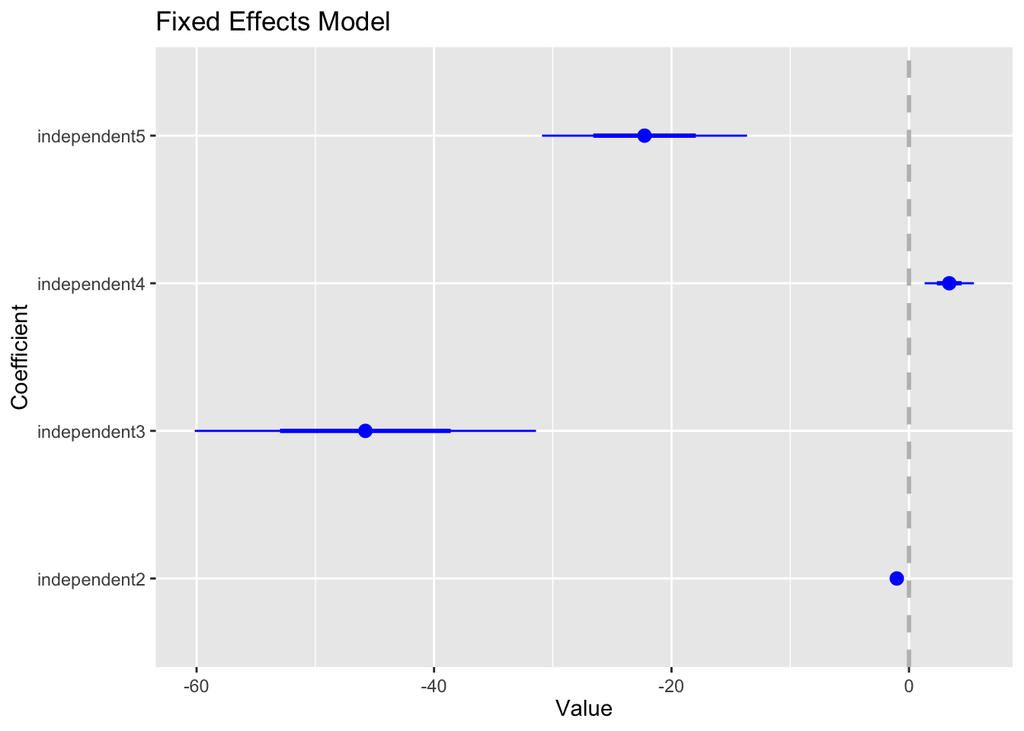

```r
coefplot(fixed_effects_model, title = "Fixed Effects Model")
```

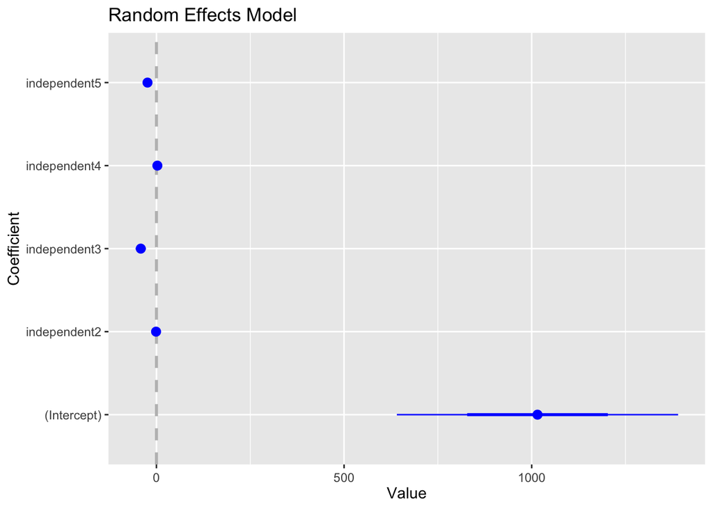

```r
coefplot(random_effects_model, title = "Random Effects Model")
```

```r
residuals_fixed <- residuals(fixed_effects_model)
residuals_random <- residuals(random_effects_model)
```

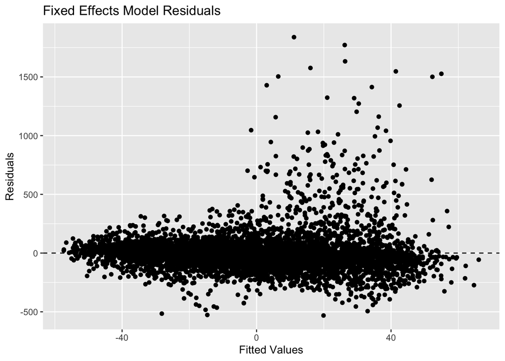

```r
ggplot() +
  geom_point(aes(x = fitted(fixed_effects_model), y = residuals_fixed)) +
  geom_hline(yintercept = 0, linetype = "dashed") +
  labs(x = "Fitted Values", y = "Residuals", title = "Fixed Effects Model Residuals")
```

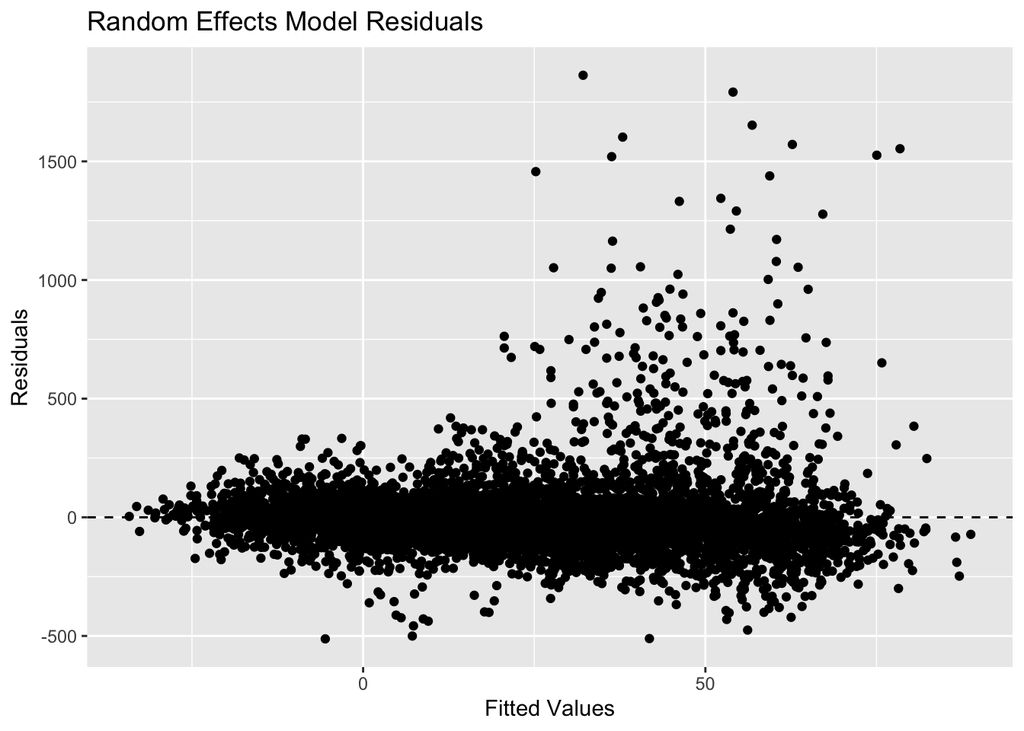

```r
ggplot() +
  geom_point(aes(x = fitted(random_effects_model), y = residuals_random)) +
  geom_hline(yintercept = 0, linetype = "dashed") +
  labs(x = "Fitted Values", y = "Residuals", title = "Random Effects Model Residuals")
```